# Создание бинарного классификатора изображений по типу эмоций:

Класс 1 - наличие эмоции  
Класс 0 - нейтральная эмоция

## Дано:

В архиве "all.zip" лежит папка all, в которой массив фотографий людей, показывающих различные виды эмоций (для самостоятельного запуска кода архив необходимо скачать по ссылке и после разархивации папку all положить в репозитоий проекта)  
В репозитории уже имеется файл _label*dataset.csv*, в котором находится код соответсвующей эмоции для каждого номера фотографии из папки "all", которая появляется в текущей директории проекта при запуске кода:  
0 - neutral,  
1 - anger,  
2 - contempt,  
3 - disgust,  
4 - fear,  
5 - happiness,  
6- surprise

Загрузить архив *all.zip* с фотографиями можно по данной ссылке. После загрузки и разархивации папку *all* надо положить в репозитоий проекта, где уже лежат файлы _emotion_class*binar.ipynb*, _emotion_class*multy.ipynb* и _label*dataset.csv*

Работу выполнил **Колесников Дмитрий**

Загрузим необходимые библиотеки:

```python
import pandas as pd
import numpy as np
import os
import seaborn as sns
import cv2
from  matplotlib import pyplot as plt
import matplotlib.image as mpimg
%matplotlib inline
from tqdm import tqdm
from scipy.ndimage.filters import gaussian_filter

import PIL.Image
import PIL.ImageDraw

import collections
from matplotlib import pyplot
import pylab as pl
import glob
import zipfile

from sklearn.decomposition import PCA
from sklearn.discriminant_analysis import LinearDiscriminantAnalysis
from sklearn.preprocessing import StandardScaler
from sklearn.model_selection import train_test_split
from sklearn.metrics import accuracy_score
from sklearn import preprocessing
from sklearn.model_selection import cross_val_score
from sklearn.metrics import confusion_matrix, ConfusionMatrixDisplay
from sklearn.metrics import precision_score, \
    recall_score, confusion_matrix, classification_report, \
    accuracy_score, f1_score
```

```python
#!pip install face_recognition
```

```python
import face_recognition as fr
```

```python
path = os.getcwd()
```

```python
list_im = os.listdir('all')
```

Загрузим датафрейм и посмотрим его содержимое:

```python
df = pd.read_csv('label_dataset.csv', index_col=0)
```

```python
df.shape
```

```
(920, 2)
```

```python
df.head()
```

|  | label | file name |
| --- | --- | --- |
| 0 | 1 | S010_004_00000019.png |
| 1 | 1 | S011_004_00000021.png |
| 2 | 1 | S014_003_00000030.png |
| 3 | 1 | S022_005_00000032.png |
| 4 | 1 | S026_003_00000015.png |

```python
dirName = 'all'
allFiles = list()
for entry in list_im:
    fullPath = os.path.join(dirName, entry)
    if os.path.isdir(fullPath):
        allFiles = allFiles + getListOfFiles(fullPath)
    else:
        allFiles.append(fullPath)
```

Получим список фотографий для каждого номера эмоции:

```python
df_new = df.groupby('label', as_index = False)['file name'].\
    apply(np.asarray).to_frame().reset_index().\
    rename(columns={"index": "category", 'file name': 'file'})
df_new
```

|  | category | file |
| --- | --- | --- |
| 0 | 0 | [S005_001_00000001.png, S010_001_00000001.png,... |
| 1 | 1 | [S010_004_00000019.png, S011_004_00000021.png,... |
| 2 | 2 | [S138_008_00000009.png, S139_002_00000013.png,... |
| 3 | 3 | [S005_001_00000011.png, S011_005_00000020.png,... |
| 4 | 4 | [S011_003_00000014.png, S032_004_00000014.png,... |
| 5 | 5 | [S010_006_00000015.png, S011_006_00000013.png,... |
| 6 | 6 | [S010_002_00000014.png, S011_001_00000016.png,... |

Продемонстрируем как пример виды эмоций по имеющимся фото из папки all:

```
S005_001_00000001.png
S010_004_00000019.png
S138_008_00000009.png
S005_001_00000011.png
S011_003_00000014.png
S010_006_00000015.png
S010_002_00000014.png
```

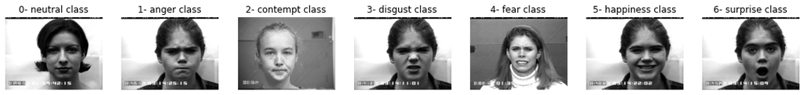

```python
names = ['0- neutral', '1- anger', '2- contempt', '3- disgust',
         '4- fear', '5- happiness', '6- surprise']
fig, axes = plt.subplots(1, 7, figsize=(19, 5))
for i in range(df_new.shape[0]):
    print(df_new.file[i][0])
    image = plt.imread(os.path.join("all", str(df_new.file[i][1])))
    axes[i].imshow(image, cmap='gray')
    axes[i].set_title(str(names[i]) + " class")
    axes[i].axis('off')
plt.show()
```

## Предобработка изображений

Визуализируем применение фильтра Гаусса к одному изображению (до/после) Визуализируем применение эквализации гистограммы к одному изображению (до/после)

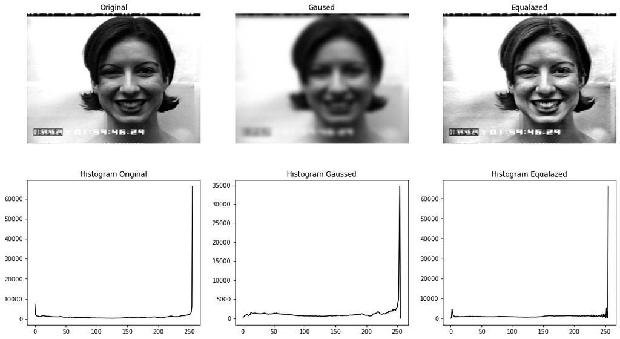

```python
img_files_list = allFiles
image_1 = cv2.imread(img_files_list[10])
image_1 = cv2.cvtColor(image_1, cv2.COLOR_BGR2GRAY);
image_GF_1 = gaussian_filter(image_1, 7)
# эквализация гистограммы
clahe_1 = cv2.createCLAHE(clipLimit=2.0, tileGridSize=(8,8))
image_CLAHE_1 = clahe_1.apply(image_1)
plt.figure(figsize=(18, 10))
plt.subplot(2, 3, 1)
plt.imshow(image_1, cmap='gray')
plt.title('Original')
plt.axis('off')
plt.subplot(2, 3, 2)
plt.imshow(image_GF_1, cmap='gray')
plt.title('Gaused')
plt.axis('off')
plt.subplot(2, 3, 3)
plt.imshow(image_CLAHE_1, cmap='gray')
plt.title('Equalazed')
plt.axis('off')
plt.subplot(2, 3, 4)
plt.title("Histogram Original")
hist_1 = cv2.calcHist([image_1], [0],
                      None, [256], [0, 256])
plt.plot(hist_1, color='black')
plt.subplot(2, 3, 5)
plt.title("Histogram Gaussed")
hist_1 = cv2.calcHist([image_GF_1], [0],
                      None, [256], [0, 256])
plt.plot(hist_1, color='black')
plt.subplot(2, 3, 6)
plt.title("Histogram Equalazed")
hist_1 = cv2.calcHist([image_CLAHE_1], [0],
                      None, [256], [0, 256])
plt.plot(hist_1, color='black')
plt.show()
```

Сделаем функцию предпроцессинга, которая с помощью модуля face_recognition, реализующий детектирование лица на изображениях по гистограмме градиентов, позволит сделать вырезание из исходных фоток лишь область лиц с заданным размером на выходе. В процессе преодобработки применеим фильтрацию гаусса и эквализацию гитограммы исодной фотки для убирания артефактов возможной засветки

То есть на вход подается массив необработанных фоток некого размера а на выходе получается массив фоток размером 64 на 64, состоящий исключительно из вырезанных областей лиц

```python
def ImagePreProcessing(data, sigma_GF, IMG_HEIGHT, IMG_WIDTH):
    X = []
    # При помощи флагов выведу лишь определенные фотки в качестве пояснения к работе кода
    flag = 0
    for image in data:
        image = cv2.imread(image)
        image = cv2.cvtColor(image, cv2.COLOR_BGR2GRAY);

        if flag in [0, 10, 20]:
            plt.figure(figsize=(8, 8))
            plt.subplot(2, 2, 1)
            plt.imshow(image, cmap='gray')
            plt.title('Original')
            plt.subplot(2,2,3)
            plt.title("Histogram Original")
            hist_1 = cv2.calcHist([image], [0],
                                  None, [256], [0, 256])
            plt.plot(hist_1, color='black')

        image_GF = gaussian_filter(image, sigma_GF)

        # Face detection + crop
        face_loc = fr.face_locations(img=image_GF, model='hog')
        if len(face_loc)>1:
            face_loc=[(face_loc[0])]

        a = collections.deque(*face_loc)
        a.rotate(1)
        shifted = list(a)
        img = PIL.Image.fromarray(image_GF)
        img2 = img.crop((shifted))
        image_CROPPED = np.array(img2)

        # выполните эквализацию гистограммы с cv2.createCLAHE
        clahe = cv2.createCLAHE(clipLimit=2.0, tileGridSize=(8,8))
        image_CLAHE = clahe.apply(image_CROPPED)

        # Scale
        image_SCALED = PIL.Image.fromarray(image_CLAHE).\
            resize((IMG_HEIGHT, IMG_WIDTH))

        X.append(np.array(image_SCALED))
        if flag in [0, 10, 20]:
            plt.subplot(2, 2, 2)
            plt.imshow(image_SCALED, cmap='gray')

            plt.title('Cropped')
            plt.subplot(2, 2, 4)
            plt.title("Histogram Cropped")
            hist_1 = cv2.calcHist([ np.array(image_SCALED)], [0],
                                  None, [256], [0, 256])
            plt.plot(hist_1, color='black')
            plt.show()

        flag = flag + 1
    X = np.array(X)
    return X
```

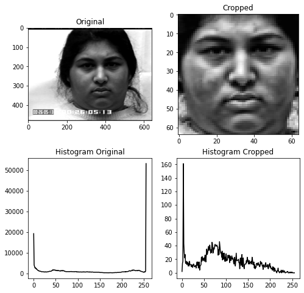

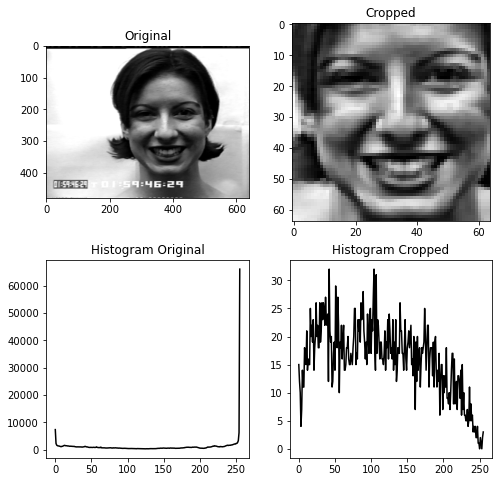

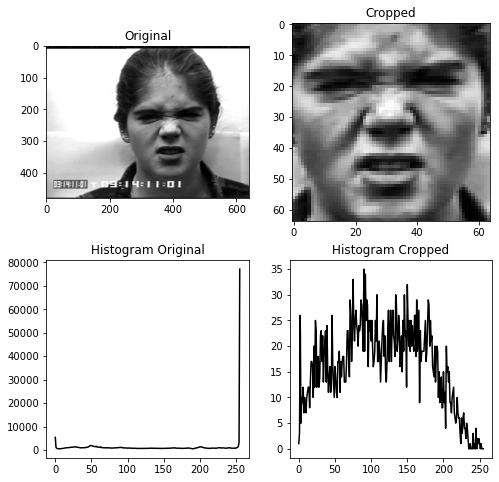

```python
#применение функции для преобработки данных с размером 64 на 64 и выведем
X_processed = ImagePreProcessing(img_files_list, 1, 64, 64)
```

```python
X_processed.shape
```

```
(920, 64, 64)
```

## Извлечение признаков с фильтрами Габбора

Напишем функцию (GaborFiltersFeatures) для создания 8 фильтров Габора (cv2.getGaborKernel) со следующими параметрами:

```python
theta_range = np.arange(0, np.pi, np.pi/8)  # Фазы синусоиды
lamda = 3*np.pi/4  # Фиксированная частота синусоиды
gamma = 0.5  # Параметр Гаусса
sigma = 0.75  # Параметр Гаусса
ksize = (9,9)
phi = 0
```

На выходе для каждой фотки размером 64 на 64 будет получено 8 отфильтрованных изображений с разными фильтрами из банка фильтров Габара. После этого в начале будет добавлено исходное изображение и после операции flattern на выходе мы получим вектор признаков размером 9 (число фоток, полученных из одной) х 64 х 64 (размер исходной фотки фотки после предобработки)

Следовательно каждой из 920 фоток будет соответствовть вектор признаков размера 9 х 64 х 64 = 36864

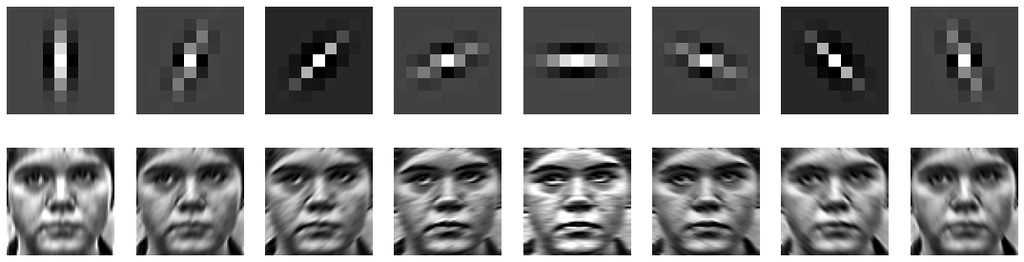

```python
def GaborFiltersFeatures(X_processed, ksize, sigma, theta_range, lambd, gamma, psi):
    result = []
    flag = 0
    final = []
    res = []
    for im in tqdm(X_processed):
        final = np.asarray(im.flatten())
        for i in range(0, theta_range.size):
            g_kernel = cv2.getGaborKernel(ksize, sigma, theta_range[i],
                                          lambd, gamma, psi, ktype=cv2.CV_32F)
            if flag == 0:
                plt.subplot(2, theta_range.size, i + 1)
                plt.imshow(g_kernel, cmap='gray')
                plt.axis('off')
            filtered_img = cv2.filter2D(im, cv2.CV_8UC3, g_kernel)
            if flag == 15:
                plt.subplot(2, theta_range.size, 8 + i +1)
                plt.imshow(filtered_img, cmap='gray')
                plt.axis('off')
            features = filtered_img.flatten()
            final = np.concatenate((final, features), axis=None)

        res.append(final)
        flag = flag + 1
    return np.asarray(res)


fig, axes = plt.subplots(2, 7, figsize=(19, 5))
X_features = GaborFiltersFeatures(X_processed, ksize, sigma, theta_range, lamda, gamma, phi)
```

```python
X_features.shape
```

```
(920, 36864)
```

Вот, как выглядит исзодный массив данных перед стадиями разделения выборки на тренировочную и тестовую

```python
data_features = pd.DataFrame(data=X_features,
          index=pd.RangeIndex(range(0, 920)),
          columns=pd.RangeIndex(range(0, 36864)))
data_features
```

|  | 0 | 1 | 2 | 3 | 4 | 5 | 6 | 7 | 8 | 9 | ... | 36854 | 36855 | 36856 | 36857 | 36858 | 36859 | 36860 | 36861 | 36862 | 36863 |
| --- | --- | --- | --- | --- | --- | --- | --- | --- | --- | --- | --- | --- | --- | --- | --- | --- | --- | --- | --- | --- | --- |
| 0 | 30 | 28 | 20 | 9 | 6 | 3 | 3 | 3 | 3 | 6 | ... | 35 | 56 | 52 | 27 | 26 | 58 | 46 | 32 | 105 | 135 |
| 1 | 26 | 24 | 20 | 18 | 10 | 4 | 3 | 4 | 3 | 3 | ... | 37 | 59 | 57 | 33 | 27 | 53 | 40 | 31 | 105 | 134 |
| 2 | 36 | 41 | 26 | 17 | 21 | 25 | 23 | 48 | 63 | 46 | ... | 56 | 63 | 72 | 72 | 69 | 81 | 110 | 170 | 187 | 178 |
| 3 | 41 | 37 | 17 | 8 | 13 | 21 | 26 | 50 | 53 | 34 | ... | 55 | 71 | 78 | 76 | 77 | 98 | 134 | 179 | 179 | 173 |
| 4 | 35 | 46 | 29 | 16 | 13 | 16 | 16 | 36 | 63 | 52 | ... | 30 | 44 | 57 | 74 | 81 | 94 | 123 | 170 | 181 | 174 |
| ... | ... | ... | ... | ... | ... | ... | ... | ... | ... | ... | ... | ... | ... | ... | ... | ... | ... | ... | ... | ... | ... |
| 915 | 124 | 118 | 96 | 59 | 58 | 64 | 75 | 83 | 84 | 67 | ... | 43 | 43 | 46 | 73 | 61 | 76 | 100 | 81 | 116 | 41 |
| 916 | 106 | 89 | 76 | 99 | 105 | 106 | 54 | 67 | 67 | 90 | ... | 109 | 125 | 139 | 107 | 25 | 4 | 30 | 31 | 102 | 139 |
| 917 | 146 | 114 | 111 | 101 | 98 | 106 | 93 | 48 | 55 | 80 | ... | 150 | 155 | 142 | 120 | 82 | 28 | 21 | 72 | 95 | 38 |
| 918 | 116 | 136 | 140 | 106 | 92 | 57 | 57 | 91 | 70 | 60 | ... | 95 | 147 | 135 | 107 | 30 | 6 | 18 | 34 | 52 | 153 |
| 919 | 80 | 98 | 125 | 89 | 48 | 93 | 84 | 99 | 79 | 99 | ... | 103 | 21 | 37 | 24 | 12 | 31 | 47 | 74 | 120 | 174 |

920 rows × 36864 columns

Но перед процедурой снижения размерности необходимо сначала отделить тренировочную и тестовую выборки. Инач емы при поиске проекций с максимальными дисперсиями будем учитывать данные, которые машина знать не должна, ведь они отнесены к тестовой выборке

Разобьем данные на train и test:

## Задание метки класса

```python
df.head()
```

|  | label | file name |
| --- | --- | --- |
| 0 | 1 | S010_004_00000019.png |
| 1 | 1 | S011_004_00000021.png |
| 2 | 1 | S014_003_00000030.png |
| 3 | 1 | S022_005_00000032.png |
| 4 | 1 | S026_003_00000015.png |

```python
data_features['file name'] = list_im
```

```python
data_features.head()
```

|  | 0 | 1 | 2 | 3 | 4 | 5 | 6 | 7 | 8 | 9 | ... | 36855 | 36856 | 36857 | 36858 | 36859 | 36860 | 36861 | 36862 | 36863 | file name |
| --- | --- | --- | --- | --- | --- | --- | --- | --- | --- | --- | --- | --- | --- | --- | --- | --- | --- | --- | --- | --- | --- |
| 0 | 30 | 28 | 20 | 9 | 6 | 3 | 3 | 3 | 3 | 6 | ... | 56 | 52 | 27 | 26 | 58 | 46 | 32 | 105 | 135 | S005_001_00000001.png |
| 1 | 26 | 24 | 20 | 18 | 10 | 4 | 3 | 4 | 3 | 3 | ... | 59 | 57 | 33 | 27 | 53 | 40 | 31 | 105 | 134 | S005_001_00000011.png |
| 2 | 36 | 41 | 26 | 17 | 21 | 25 | 23 | 48 | 63 | 46 | ... | 63 | 72 | 72 | 69 | 81 | 110 | 170 | 187 | 178 | S010_001_00000001.png |
| 3 | 41 | 37 | 17 | 8 | 13 | 21 | 26 | 50 | 53 | 34 | ... | 71 | 78 | 76 | 77 | 98 | 134 | 179 | 179 | 173 | S010_002_00000001.png |
| 4 | 35 | 46 | 29 | 16 | 13 | 16 | 16 | 36 | 63 | 52 | ... | 44 | 57 | 74 | 81 | 94 | 123 | 170 | 181 | 174 | S010_002_00000014.png |

5 rows × 36865 columns

Объединим таблицы чтоб определить метку класса

```python
data_full = data_features.merge(df, how='left', on='file name')
```

```python
data_full.head()
```

|  | 0 | 1 | 2 | 3 | 4 | 5 | 6 | 7 | 8 | 9 | ... | 36856 | 36857 | 36858 | 36859 | 36860 | 36861 | 36862 | 36863 | file name | label |
| --- | --- | --- | --- | --- | --- | --- | --- | --- | --- | --- | --- | --- | --- | --- | --- | --- | --- | --- | --- | --- | --- |
| 0 | 30 | 28 | 20 | 9 | 6 | 3 | 3 | 3 | 3 | 6 | ... | 52 | 27 | 26 | 58 | 46 | 32 | 105 | 135 | S005_001_00000001.png | 0 |
| 1 | 26 | 24 | 20 | 18 | 10 | 4 | 3 | 4 | 3 | 3 | ... | 57 | 33 | 27 | 53 | 40 | 31 | 105 | 134 | S005_001_00000011.png | 3 |
| 2 | 36 | 41 | 26 | 17 | 21 | 25 | 23 | 48 | 63 | 46 | ... | 72 | 72 | 69 | 81 | 110 | 170 | 187 | 178 | S010_001_00000001.png | 0 |
| 3 | 41 | 37 | 17 | 8 | 13 | 21 | 26 | 50 | 53 | 34 | ... | 78 | 76 | 77 | 98 | 134 | 179 | 179 | 173 | S010_002_00000001.png | 0 |
| 4 | 35 | 46 | 29 | 16 | 13 | 16 | 16 | 36 | 63 | 52 | ... | 57 | 74 | 81 | 94 | 123 | 170 | 181 | 174 | S010_002_00000014.png | 6 |

5 rows × 36866 columns

Посмотрм число фоток кадого класса:

```python
data_full.label.value_counts()
```

```
0    621
6     83
5     69
3     59
1     45
4     25
2     18
Name: label, dtype: int64
```

Выборки слишком неравномерные. Посмотрим, что в случае с разбивкой на эмоциональных и неэмоцинальных:

Сделаем бинарную классификацию:  
0 - нет эмоций  
1 - есть эмоция

```python
def func(x):
    if x != 0:
        return 1
    else:
        return 0

data_full['binar'] = data_full['label'].apply(lambda x : func(x))
```

```python
data_full.head()
```

|  | 0 | 1 | 2 | 3 | 4 | 5 | 6 | 7 | 8 | 9 | ... | 36857 | 36858 | 36859 | 36860 | 36861 | 36862 | 36863 | file name | label | binar |
| --- | --- | --- | --- | --- | --- | --- | --- | --- | --- | --- | --- | --- | --- | --- | --- | --- | --- | --- | --- | --- | --- |
| 0 | 30 | 28 | 20 | 9 | 6 | 3 | 3 | 3 | 3 | 6 | ... | 27 | 26 | 58 | 46 | 32 | 105 | 135 | S005_001_00000001.png | 0 | 0 |
| 1 | 26 | 24 | 20 | 18 | 10 | 4 | 3 | 4 | 3 | 3 | ... | 33 | 27 | 53 | 40 | 31 | 105 | 134 | S005_001_00000011.png | 3 | 1 |
| 2 | 36 | 41 | 26 | 17 | 21 | 25 | 23 | 48 | 63 | 46 | ... | 72 | 69 | 81 | 110 | 170 | 187 | 178 | S010_001_00000001.png | 0 | 0 |
| 3 | 41 | 37 | 17 | 8 | 13 | 21 | 26 | 50 | 53 | 34 | ... | 76 | 77 | 98 | 134 | 179 | 179 | 173 | S010_002_00000001.png | 0 | 0 |
| 4 | 35 | 46 | 29 | 16 | 13 | 16 | 16 | 36 | 63 | 52 | ... | 74 | 81 | 94 | 123 | 170 | 181 | 174 | S010_002_00000014.png | 6 | 1 |

5 rows × 36867 columns

```python
data_full.binar.value_counts()
```

```
0    621
1    299
Name: binar, dtype: int64
```

## Разбивка данных на train и test:

```python
y = data_full.binar
X = data_full.drop(['file name', 'label', 'binar'], axis=1)
```

```python
X_train, X_test, y_train, y_test = train_test_split(X, y, test_size=0.2, stratify=y)
```

```python
y_test.value_counts()
```

```
0    124
1     60
Name: binar, dtype: int64
```

```python
y_train.value_counts()
```

```
0    497
1    239
Name: binar, dtype: int64
```

```python
X_train.shape
```

```
(736, 36864)
```

```python
X_test.shape
```

```
(184, 36864)
```

```python
X_train = np.array(X_train)
```

## Применим LDA классификатор без уменьшения размерности данных:

```
Точность модели на обучающей выборке:  0.98
Точность модели на тестовой выборке:  0.76
Матрица несоответствий метода "Линейный дискриминантный анализ без МГК":
```

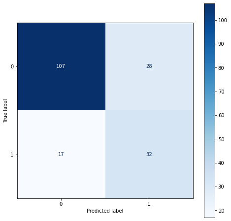

```python
LDA_model = LinearDiscriminantAnalysis()
LDA_model.fit(X_train, y_train)
LDA_prediction = LDA_model.predict(X_test)

LDA_train_accuracy = LDA_model.score(X_train, y_train)
LDA_test_accuracy = LDA_model.score(X_test, y_test)
print ('Точность модели на обучающей выборке: ', round (LDA_train_accuracy, 2))
print ('Точность модели на тестовой выборке: ', round (LDA_test_accuracy, 2))

print('Матрица несоответствий метода "Линейный дискриминантный анализ без МГК":\n')

fig, ax = plt.subplots(figsize=(8, 8))
disp = ConfusionMatrixDisplay(confusion_matrix(LDA_prediction, y_test))
disp.plot(cmap = 'Blues', ax=ax);
```

```python
print ('F1 score:', f1_score(y_test, LDA_model.predict(X_test)))
print ('Recall:', recall_score(y_test, LDA_model.predict(X_test)))
print ('Precision:', precision_score(y_test, LDA_model.predict(X_test)))
print ('\n clasification report:\n', classification_report(y_test, LDA_model.predict(X_test)))
```

```
F1 score: 0.5871559633027523
Recall: 0.5333333333333333
Precision: 0.6530612244897959

 clasification report:
               precision    recall  f1-score   support

           0       0.79      0.86      0.83       124
           1       0.65      0.53      0.59        60

    accuracy                           0.76       184
   macro avg       0.72      0.70      0.71       184
weighted avg       0.75      0.76      0.75       184
```

**Итог: accuracy = 76%**

## Применение снижения размерности

Напишием код примененеия PCA к исходным данным для снижения размерности признаков (90% дисперсии)

```python
# Шаг 1 - Стандартизация X_train
scaler = StandardScaler()
scaler.fit(X_train)
scaled_data = scaler.transform(X_train)
scaled_data.shape
```

```
(736, 36864)
```

```python
# Стандартизованные данные
pd.DataFrame(data=scaled_data,
          index=pd.RangeIndex(range(0, scaled_data.shape[0])),
          columns=pd.RangeIndex(range(0, 36864)))
```

|  | 0 | 1 | 2 | 3 | 4 | 5 | 6 | 7 | 8 | 9 | ... | 36854 | 36855 | 36856 | 36857 | 36858 | 36859 | 36860 | 36861 | 36862 | 36863 |
| --- | --- | --- | --- | --- | --- | --- | --- | --- | --- | --- | --- | --- | --- | --- | --- | --- | --- | --- | --- | --- | --- |
| 0 | -0.623553 | -0.604101 | -0.444232 | 0.101028 | 0.721429 | 1.006168 | 1.022014 | 1.183750 | 1.396644 | 1.398926 | ... | -0.461362 | 0.358154 | 0.765806 | 1.085297 | 1.129326 | 1.631438 | 2.321452 | -0.090199 | -1.407300 | -1.064928 |
| 1 | -0.642452 | -0.784457 | -1.073265 | -1.124419 | -1.144993 | -1.185143 | -1.319690 | -1.448928 | -1.565387 | -1.683737 | ... | -0.477380 | -0.674803 | -0.876725 | -1.377861 | -1.491386 | -1.426259 | -1.478491 | -1.468145 | -1.469035 | -1.304152 |
| 2 | 0.264684 | 0.798670 | 1.442866 | 1.552711 | 1.427643 | 1.206781 | 1.080925 | 1.066089 | 0.990681 | 0.892817 | ... | -0.092934 | -0.021609 | -0.026643 | 0.011966 | -0.041630 | -0.036396 | 0.101093 | 0.246632 | 0.321303 | 0.430221 |
| 3 | 2.135651 | 3.403817 | 2.782096 | -0.162915 | -1.060920 | -0.922803 | -0.877859 | -0.742959 | -0.527924 | -0.104064 | ... | -0.973957 | -0.841899 | -0.213950 | 0.383504 | 0.822647 | 1.192535 | 1.635972 | 2.068583 | 1.478849 | -1.408813 |
| 4 | 1.871070 | 1.299660 | 1.138495 | 0.723178 | 0.452395 | 0.388897 | 0.005803 | -0.787082 | -0.783531 | -0.502816 | ... | 0.467717 | 0.555631 | 0.347969 | 0.080769 | -0.362249 | -1.104396 | -1.165555 | -0.411720 | -0.033678 | -0.840656 |
| ... | ... | ... | ... | ... | ... | ... | ... | ... | ... | ... | ... | ... | ... | ... | ... | ... | ... | ... | ... | ... | ... |
| 731 | 1.247414 | 0.678433 | -0.099279 | -0.898183 | -1.161808 | -1.200575 | -1.319690 | -1.448928 | -1.580423 | -1.699074 | ... | 0.259475 | 0.646774 | 0.448826 | 0.699999 | 1.631164 | 1.792370 | 0.384226 | -0.794482 | -0.897979 | -0.810753 |
| 732 | -0.831438 | -0.924734 | -1.052973 | -1.124419 | -1.128179 | -0.814781 | -0.391845 | -0.022281 | 0.193789 | 0.340698 | ... | 1.012349 | 1.254396 | 1.587072 | 1.621963 | 0.292928 | -1.514040 | -1.359277 | -0.304546 | -0.064546 | -0.616383 |
| 733 | -0.831438 | -0.924734 | -1.052973 | -1.124419 | -1.144993 | -1.169711 | -1.187141 | -1.243021 | -1.249638 | -1.177628 | ... | -0.173027 | 1.360730 | 0.924296 | 1.181622 | 1.212965 | 1.148644 | 0.816376 | 0.690637 | 0.151530 | -0.646286 |
| 734 | 0.283583 | 1.119304 | 1.321117 | 1.420740 | 1.461273 | 1.391962 | 1.198747 | 1.036673 | 0.975645 | 0.846807 | ... | -0.012841 | 0.525250 | 1.053969 | 0.493589 | -0.752568 | -0.577711 | -0.480075 | -0.825103 | -0.805375 | -0.601432 |
| 735 | -0.680249 | -0.363626 | 0.103635 | 1.005973 | 1.394014 | 1.330235 | 1.316568 | 1.360243 | 1.441751 | 1.444936 | ... | 0.083271 | -0.036800 | -0.646195 | -0.483418 | -0.278610 | -0.168068 | -0.062826 | -0.028957 | -0.110848 | -0.108033 |

736 rows × 36864 columns

```python
pca = PCA(n_components=scaled_data.shape[0])
pca.fit(scaled_data)
ratio = pca.explained_variance_ratio_
```

```python
pca.components_.shape
```

```
(736, 36864)
```

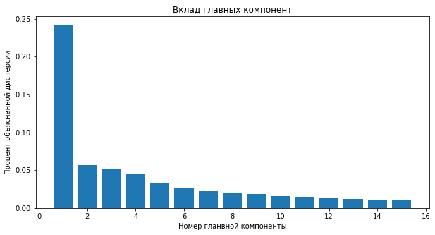

```python
fig = plt.figure(figsize = (10, 5))
plt.xlabel("Номер гланвной компоненты")
plt.ylabel("Процент объясненной дисперсии")
plt.title("Вклад главных компонент")
plt.bar(range(1, 16),ratio[:15])
plt.show()
```

```python
ss = np.cumsum(ratio)
col = -1
for i in range(len(ss)):
    if float(ss[i]) > 0.9:
        col = i
        break
print('Число главных компонент, объясняющих более 90% дисперсии равно', col+1)
```

```
Число главных компонент, объясняющих более 90% дисперсии равно 136
```

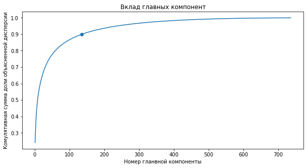

```python
fig = plt.figure(figsize = (10, 5))
plt.xlabel("Номер гланвной компоненты")
plt.ylabel("Комулятивная сумма доли объясненной дисперсии")
plt.title("Вклад главных компонент")
plt.plot(range(1, scaled_data.shape[0]+1), ss[:])
plt.scatter(col, ss[col])
plt.show()
```

```python
pca = PCA(n_components=col+1)
pca.fit(scaled_data)
x_pca = pca.transform(scaled_data)
```

```python
x_pca.shape
```

```
(736, 136)
```

```python
# Итоговые данные
data_pca = pd.DataFrame(data=x_pca,
          index=pd.RangeIndex(range(0, scaled_data.shape[0])),
          columns=pd.RangeIndex(range(0, col+1)))
X_train = data_pca
```

```python
X_train
```

|  | 0 | 1 | 2 | 3 | 4 | 5 | 6 | 7 | 8 | 9 | ... | 126 | 127 | 128 | 129 | 130 | 131 | 132 | 133 | 134 | 135 |
| --- | --- | --- | --- | --- | --- | --- | --- | --- | --- | --- | --- | --- | --- | --- | --- | --- | --- | --- | --- | --- | --- |
| 0 | -72.439998 | 24.495240 | -60.772373 | -24.270279 | -3.008755 | -7.170359 | -16.115559 | -10.637659 | 44.294395 | 17.254882 | ... | -5.082136 | 0.525675 | -1.506119 | 3.594747 | -1.402252 | 1.225048 | 10.960870 | -2.251751 | 2.734410 | 4.025959 |
| 1 | 244.384912 | 54.702008 | -11.194736 | 8.792891 | -20.251203 | -39.364367 | 15.272130 | -52.864948 | -21.706032 | -10.730405 | ... | -2.268754 | -5.746201 | -1.425231 | 10.514323 | -5.056066 | -3.755314 | -5.200347 | 0.646367 | 2.070529 | 1.106333 |
| 2 | -21.001772 | -17.191900 | -15.537655 | 62.522664 | 15.491648 | 2.691545 | -25.011367 | 38.438682 | 7.807877 | 26.956321 | ... | 7.570092 | 4.807959 | -4.850277 | 10.925068 | 13.077964 | 2.914144 | -0.553892 | -10.841766 | 5.035126 | -9.381174 |
| 3 | -71.118095 | 45.523352 | -45.319340 | -24.471260 | 20.058599 | -16.994666 | -35.983679 | -44.116795 | -3.380713 | 26.451330 | ... | 1.806806 | 0.583561 | -1.249187 | 14.822238 | 0.402524 | -0.567143 | -3.052387 | -1.840164 | 3.442742 | 0.944162 |
| 4 | -32.785345 | 31.313294 | 1.056868 | -48.490689 | -24.513411 | 30.629215 | -9.400254 | 13.904872 | -4.210510 | -4.732720 | ... | -0.831712 | 6.644991 | -10.639539 | -6.927694 | -4.461924 | -6.284844 | -0.989943 | 0.478682 | -12.535545 | 4.945166 |
| ... | ... | ... | ... | ... | ... | ... | ... | ... | ... | ... | ... | ... | ... | ... | ... | ... | ... | ... | ... | ... | ... |
| 731 | 98.609164 | 66.840480 | 28.104395 | -21.836826 | 9.131906 | -16.248701 | -15.449696 | -21.103601 | -42.846984 | -37.797777 | ... | -3.291316 | -0.376097 | 0.002074 | 4.675411 | 3.394130 | -1.289414 | -4.794347 | -2.880618 | -1.301183 | 3.840758 |
| 732 | -71.854055 | 66.812858 | -2.506993 | -31.939228 | -28.090060 | -50.203862 | 11.365473 | 31.810061 | 3.825540 | -19.821584 | ... | 4.125494 | 1.569545 | -2.731113 | 9.936599 | 3.766643 | -3.762262 | 8.588022 | -3.484773 | -2.117196 | -2.031359 |
| 733 | 257.951699 | 14.848715 | -19.186317 | 54.258400 | -22.154088 | 19.135293 | 20.277916 | -26.338451 | 23.777541 | -0.341303 | ... | 7.357299 | 3.367087 | -0.580174 | -7.804482 | 9.677313 | 3.182802 | 3.144717 | -5.040881 | -0.712674 | -2.298782 |
| 734 | -65.959557 | -50.298442 | -19.050640 | 32.840710 | -18.840345 | -3.760403 | -34.005992 | -20.586462 | -20.635598 | -10.397248 | ... | -2.557614 | 4.593891 | 7.006990 | 6.432361 | -0.605216 | 6.756132 | -9.708533 | 1.816280 | -1.637303 | 3.281449 |
| 735 | -28.418561 | -36.650742 | 58.193359 | -55.127055 | -10.567002 | -14.770604 | -22.415728 | 8.123761 | 24.084538 | -13.170107 | ... | -9.035565 | -1.686223 | 0.188567 | -17.424914 | 0.567929 | -2.308241 | -2.484020 | 7.051354 | 1.945072 | 6.144297 |

736 rows × 136 columns

Получим новый X_test как проекцию данных прошлого X_test на собственные вектора, полученные при МГК для X_train

```python
# Шаг 1 - Стандартизация X_test
scaler = StandardScaler()
scaler.fit(X_test)
scaled_data = scaler.transform(X_test)
scaled_data.shape
```

```
(184, 36864)
```

```python
# Стандартизованные данные
pd.DataFrame(data=scaled_data,
          index=pd.RangeIndex(range(0, scaled_data.shape[0])),
          columns=pd.RangeIndex(range(0, 36864)))
```

|  | 0 | 1 | 2 | 3 | 4 | 5 | 6 | 7 | 8 | 9 | ... | 36854 | 36855 | 36856 | 36857 | 36858 | 36859 | 36860 | 36861 | 36862 | 36863 |
| --- | --- | --- | --- | --- | --- | --- | --- | --- | --- | --- | --- | --- | --- | --- | --- | --- | --- | --- | --- | --- | --- |
| 0 | -0.430553 | -0.412344 | -0.224395 | 0.093270 | 0.586658 | 0.748620 | 0.810585 | 0.793766 | 0.802556 | 0.810562 | ... | 0.135055 | 0.562316 | 0.862246 | 0.929427 | 1.010276 | 1.539285 | 1.955815 | -0.182820 | -1.420794 | -0.930925 |
| 1 | -0.378238 | -0.729465 | -0.984924 | -0.945703 | -0.876427 | -1.069505 | -1.257191 | -1.280515 | -1.156735 | -1.087540 | ... | 0.828919 | 0.911864 | 0.576507 | 1.276059 | 0.359269 | 0.014465 | -0.073608 | 0.122572 | 0.290089 | 0.089087 |
| 2 | -0.343362 | -0.233963 | 0.035786 | 0.000504 | -0.127872 | -0.175850 | -0.156361 | -0.103618 | 0.139411 | 0.399306 | ... | 1.538921 | 1.595762 | 1.147985 | 1.026484 | 0.882905 | -1.122220 | -1.512915 | -1.465467 | -0.388098 | 1.051634 |
| 3 | 0.092593 | 0.539020 | 0.896384 | 1.243561 | 1.573390 | 1.441972 | 1.212240 | 1.264525 | 1.314986 | 1.190182 | ... | 1.103238 | 1.367796 | 1.733070 | 1.484038 | -0.362500 | -0.595463 | 0.315005 | 0.046224 | -0.418925 | 0.261483 |
| 4 | 0.720368 | -0.115043 | -0.584646 | -0.852938 | -0.723314 | -0.638085 | -0.572891 | -0.265441 | -0.146947 | -0.011949 | ... | -0.671765 | -0.623107 | -0.484810 | -0.637351 | -0.475718 | -0.179603 | 0.919514 | 1.466297 | 1.014517 | 1.353327 |
| ... | ... | ... | ... | ... | ... | ... | ... | ... | ... | ... | ... | ... | ... | ... | ... | ... | ... | ... | ... | ... | ... |
| 179 | 2.481625 | 1.787686 | 1.736968 | 2.820572 | 2.117794 | 0.625357 | 1.078355 | 2.117775 | 1.812344 | 0.842197 | ... | 1.877785 | 0.592712 | 0.154701 | 0.263893 | 0.118680 | 1.192735 | 1.639167 | 0.305807 | -0.973806 | -1.333183 |
| 180 | -0.622373 | -0.352884 | -0.524604 | -0.667407 | 0.025242 | 0.887290 | 1.137859 | 1.220391 | 1.345128 | 1.348357 | ... | -0.090855 | -0.471130 | -0.688909 | 0.250027 | 1.477303 | 1.414527 | 1.480843 | 1.909116 | 1.954732 | 1.669387 |
| 181 | -0.221294 | 0.122798 | 0.616189 | 1.206454 | 1.437289 | 1.133816 | 1.018850 | 0.985012 | 0.938199 | 0.889649 | ... | -0.720174 | -0.531921 | -0.471203 | -0.443237 | -0.263433 | -0.221189 | -0.188753 | -0.060663 | 0.012649 | -0.068943 |
| 182 | -0.831631 | -0.670005 | 0.135855 | 0.779734 | 1.045999 | 1.041369 | 0.884966 | 0.690787 | 0.470983 | 0.304401 | ... | -0.365174 | 0.866271 | 0.644540 | -1.316750 | -1.452229 | -1.191530 | -1.426556 | -1.358580 | -0.927566 | -0.801628 |
| 183 | -0.744440 | -0.749286 | -0.924882 | -1.149787 | -1.199667 | -1.115728 | -1.034050 | -0.898024 | -0.795020 | -0.771190 | ... | 1.264602 | 1.200621 | -0.974649 | -1.677248 | -1.296553 | -1.108358 | -1.412163 | -1.465467 | -1.328313 | -1.304450 |

184 rows × 36864 columns

```python
x_pca = pca.transform(scaled_data)
x_pca.shape
```

```
(184, 136)
```

```python
# Итоговые данные
data_pca = pd.DataFrame(data=x_pca,
          index=pd.RangeIndex(range(0, scaled_data.shape[0])),
          columns=pd.RangeIndex(range(0, col+1)))
X_test = data_pca
X_test
```

|  | 0 | 1 | 2 | 3 | 4 | 5 | 6 | 7 | 8 | 9 | ... | 126 | 127 | 128 | 129 | 130 | 131 | 132 | 133 | 134 | 135 |
| --- | --- | --- | --- | --- | --- | --- | --- | --- | --- | --- | --- | --- | --- | --- | --- | --- | --- | --- | --- | --- | --- |
| 0 | -74.041548 | 45.597144 | -58.037633 | 6.508482 | 4.774827 | -39.793105 | -47.317777 | 1.335455 | 36.633855 | 9.887000 | ... | -3.504564 | 3.063734 | 6.711302 | -0.874345 | 1.406221 | -3.228160 | 0.486308 | -0.105848 | 2.185048 | 2.860489 |
| 1 | 89.706348 | 31.088370 | 22.695913 | -20.863034 | 32.197922 | -19.724059 | -25.257458 | -0.221072 | -3.211384 | -7.864975 | ... | 4.046484 | -4.241337 | 1.630597 | 0.169631 | -3.175207 | -0.371201 | -5.820580 | -4.979467 | -0.310063 | -3.163992 |
| 2 | 31.512029 | 45.307360 | -5.105819 | -50.006733 | 0.451336 | -47.213807 | -5.494815 | 32.309058 | -13.537263 | -3.294259 | ... | -3.088210 | -8.780102 | 0.160670 | -11.367992 | 6.736813 | 5.278485 | 2.967196 | 0.371535 | -5.588723 | 0.096250 |
| 3 | -65.579124 | -25.617871 | -3.120218 | -22.807946 | -34.510062 | -5.024745 | -21.811045 | -53.027892 | -22.433125 | 38.717922 | ... | -0.167252 | 3.873350 | 6.073744 | 0.117391 | 2.526489 | 4.789695 | -0.355879 | -1.826748 | -6.040252 | 0.555533 |
| 4 | 56.177245 | -30.568634 | -66.362183 | 28.488672 | 47.892963 | 25.154917 | 18.869619 | 36.950521 | 12.550291 | 10.430248 | ... | 1.017245 | 3.790980 | 1.337874 | -3.641851 | -2.355929 | -5.517024 | -0.881953 | -2.424674 | 4.741190 | -5.546497 |
| ... | ... | ... | ... | ... | ... | ... | ... | ... | ... | ... | ... | ... | ... | ... | ... | ... | ... | ... | ... | ... | ... |
| 179 | -127.532821 | 2.070962 | -40.547025 | 32.032612 | 55.561412 | 43.237684 | -24.184036 | -0.412219 | -17.466100 | -37.244438 | ... | 8.812335 | -0.257447 | 6.321995 | -15.781432 | -1.140735 | -9.598012 | 2.686674 | -4.308870 | 12.589789 | -3.474225 |
| 180 | -73.684872 | -15.434663 | -39.355234 | 34.862184 | 11.245086 | 14.861169 | -65.789278 | -20.743587 | 22.900546 | -40.952081 | ... | 10.481956 | 0.204948 | 0.624030 | -3.149074 | 1.474102 | 1.229767 | 1.417256 | -2.267976 | -0.474537 | 1.618238 |
| 181 | -14.360525 | -59.038550 | -58.186653 | -12.395725 | -2.364683 | 12.650906 | 14.932918 | 9.350507 | -34.935599 | 13.536585 | ... | 0.689929 | -5.878061 | 2.400471 | -0.561514 | 7.797357 | 4.379332 | 5.399639 | -2.133295 | 0.709002 | -3.095443 |
| 182 | 56.096842 | -22.242472 | -26.246905 | 8.997797 | -59.654159 | -24.938920 | -7.395719 | -50.900701 | 22.920772 | 14.929018 | ... | -2.420344 | 3.310230 | -7.462874 | 3.114353 | 5.348096 | -5.564272 | -1.855987 | -0.378965 | 1.359064 | 1.895493 |
| 183 | 22.492489 | 53.904070 | 14.469211 | -49.242344 | -55.328884 | 25.235587 | -23.526431 | 33.564372 | -19.886897 | -9.807292 | ... | -1.370827 | 4.419043 | -2.935835 | -0.855485 | -0.701542 | -4.334352 | 3.075558 | 9.483850 | 6.526992 | 2.186560 |

184 rows × 136 columns

```python
X_train.shape
```

```
(736, 136)
```

```python
X_test.shape
```

```
(184, 136)
```

# ML (Машинное обучение после снижения размерности данных)

Загрузим необходимые библиотеки для машинного обучения

```python
from sklearn.tree import plot_tree
from sklearn.metrics import confusion_matrix
from sklearn import tree
from sklearn.tree import DecisionTreeClassifier
from sklearn.model_selection import train_test_split
from sklearn.model_selection import GridSearchCV
from sklearn.model_selection import cross_val_score
from sklearn.ensemble import RandomForestClassifier
from sklearn.model_selection import GridSearchCV
import random
from sklearn.ensemble import AdaBoostClassifier
from sklearn.tree import DecisionTreeClassifier
from sklearn.datasets import make_gaussian_quantiles
from sklearn.datasets import make_classification
from sklearn.model_selection import RepeatedStratifiedKFold
from sklearn.model_selection import GridSearchCV
from sklearn.ensemble import GradientBoostingClassifier
from sklearn.neighbors import KNeighborsClassifier
from sklearn.naive_bayes import GaussianNB
from sklearn.linear_model import LogisticRegression
from sklearn.svm import SVC
random.seed(17)
```

```python
# Импортируем модули, необходимые для визуализации дерева решений.
from IPython.display import SVG
from graphviz import Source
from IPython.display import display
from IPython.display import HTML
```

**Positive class:**  
Позитивным классом считается класс изображений, на которых есть какие-то эмоции  
**Negative class:**  
Негативным классом считается класс нейтральной эмоции

Для оценки качества предсказания будем использовать метрику accuracy так как нет предпочтения какой-то конкретной эмоции в процессе классификации

## Классификатор Tree

```python
# Зададим диапазон исследуемых значений.
max_depth_values = range(1, 51)
scores_iris_data = pd.DataFrame()
rs = np.random.seed(17)
scores_data=pd.DataFrame()

for max_depth in max_depth_values:
    # Изменяем глубину обучения дерева по циклу от 1 до 50 с шагом 1.
    clf = tree.DecisionTreeClassifier(criterion='entropy', max_depth=max_depth, random_state=rs)
    # Обучаем дерево решений (с ограниченной глубиной) на подмножестве train.
    clf.fit(X_train, y_train)
    # Записываем в отдельную переменную число правильных ответов на обученной модели дерева
    train_score = clf.score(X_train, y_train)
    No_validation_score = clf.score(X_test, y_test)
    # Записываем в отдельную переменную число правильных ответов на обученной модели дерева
    test_val_score = cross_val_score(clf, X_train, y_train, cv=5).mean()
    # Создаем временный DataFrame.
    temp_score_data = pd.DataFrame({'max_depth':[max_depth],
                                    'Train_score':[train_score],
                                    'Test_score':[No_validation_score],
                                    'Validation_score':[test_val_score]})
    # Наращиваем DataFrame "scores_iris_data".
    scores_data = scores_data.append(temp_score_data)
scores_data.head(10)
```

|  | max_depth | Train_score | Test_score | Validation_score |
| --- | --- | --- | --- | --- |
| 0 | 1 | 0.732337 | 0.717391 | 0.709248 |
| 0 | 2 | 0.786685 | 0.750000 | 0.728314 |
| 0 | 3 | 0.801630 | 0.744565 | 0.726908 |
| 0 | 4 | 0.822011 | 0.760870 | 0.739162 |
| 0 | 5 | 0.865489 | 0.782609 | 0.739125 |
| 0 | 6 | 0.883152 | 0.804348 | 0.735043 |
| 0 | 7 | 0.900815 | 0.788043 | 0.730980 |
| 0 | 8 | 0.922554 | 0.788043 | 0.724205 |
| 0 | 9 | 0.925272 | 0.793478 | 0.743197 |
| 0 | 10 | 0.949728 | 0.798913 | 0.717347 |

Обратим внимание, что кросс-валидация будет менее информативна так как данные будут валидироваться из трейновой выборки, которая и является той, на которой мы МГК обучали. Тестовая не участвовала в обучении МГК (PCA) так что там не будет никаких подгонов при расчете

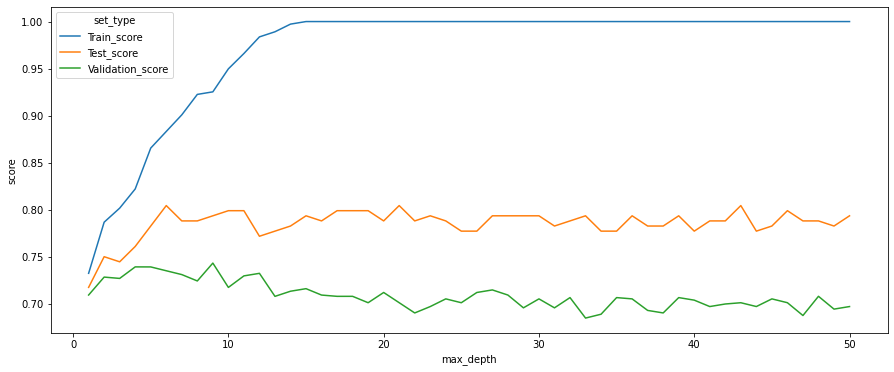

```python
fig = plt.figure(figsize = (15, 6))
scores_data_long = pd.melt(scores_data, id_vars=['max_depth'],
                           value_vars=['Train_score','Test_score','Validation_score'],
                           var_name='set_type', value_name='score')
sns.lineplot(x='max_depth', y='score', hue='set_type', data=scores_data_long);
```

```python
#Подбор лучших параметров:
par = {'max_depth':range(1, 8), 'min_samples_split':range(2, 6),
     'min_samples_leaf':range(2, 6)}
search = GridSearchCV(clf,par,cv=5)
search.fit(X_train, y_train)
search.best_params_
```

```
{'max_depth': 5, 'min_samples_leaf': 5, 'min_samples_split': 2}
```

```python
best_tree=search.best_estimator_
clf_best=best_tree
graph=Source(tree.export_graphviz(best_tree, out_file=None
                                  , feature_names=list(X_train)
                                  , class_names=['Без эмоций','Эмоция']
                                  , filled=True))
display(SVG(graph.pipe(format='svg')))
```

[figure not shown]

```python
train_accuracy = clf_best.score(X_train, y_train)
test_accuracy = clf_best.score(X_test, y_test)
print ('Точность модели на обучающей выборке: ', round (train_accuracy, 2))
print ('Точность модели на тестовой выборке: ', round (test_accuracy, 2))
```

```
Точность модели на обучающей выборке:  0.86
Точность модели на тестовой выборке:  0.78
```

```
Матрица несоответствий метода "Дерево решений":
```

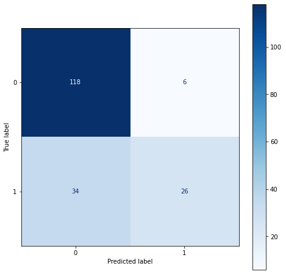

```python
print('Матрица несоответствий метода "Дерево решений":\n')
fig, ax = plt.subplots(figsize=(8, 8))
disp = ConfusionMatrixDisplay(confusion_matrix(y_test, clf_best.predict(X_test)))
disp.plot(cmap = 'Blues', ax=ax);
```

**Высокий precision** в данном случае означает то, что практически все найденные фотки с эмоцией точно являются фотками с эмоцией

**Высокий recall** в данном случае означает то, что практически все фотки с классом эмоциями найдены благодаря классификации (то есть при recall = 1 мы можем иметь хоть все 1 - "эмоции" в результате предстказания классов)

```python
print ('F1 score:', f1_score(y_test, clf_best.predict(X_test)))
print ('Recall:', recall_score(y_test, clf_best.predict(X_test)))
print ('Precision:', precision_score(y_test, clf_best.predict(X_test)))
print ('\n clasification report:\n', classification_report(y_test, clf_best.predict(X_test)))
```

```
F1 score: 0.5652173913043479
Recall: 0.43333333333333335
Precision: 0.8125

 clasification report:
               precision    recall  f1-score   support

           0       0.78      0.95      0.86       124
           1       0.81      0.43      0.57        60

    accuracy                           0.78       184
   macro avg       0.79      0.69      0.71       184
weighted avg       0.79      0.78      0.76       184
```

**Итог: accuracy = 78%**

## Random Forest

Основная идея бэггинга заключается в том, чтобы обучить несколько одинаковых моделей на разных образцах. Распределение выборки неизвестно, поэтому модели получатся разными. Рандомный лес - бэггинг на деревьях

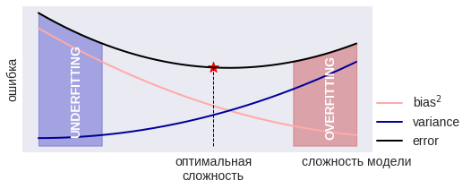

Бэггинг позволяет снизить дисперсию (variance) обучаемого классификатора, уменьшая величину, на сколько ошибка будет отличаться, если обучать модель на разных наборах данных, или другими словами, предотвращает переобучение. Эффективность бэггинга достигается благодаря тому, что базовые алгоритмы, обученные по различным подвыборкам, получаются достаточно различными, и их ошибки взаимно компенсируются при голосовании, а также за счёт того, что объекты-выбросы могут не попадать в некоторые обучающие подвыборки.

```python
clf = RandomForestClassifier(random_state=17)
par = {'n_estimators': range(13, 20), 'max_depth' : range(3, 10),
     'min_samples_split' : range(2, 7),
     'min_samples_leaf': range(1,5)}
search = GridSearchCV(clf, par, cv=5, n_jobs=-1)
search.fit(X_train, y_train)
search.best_params_
```

```
{'max_depth': 9,
 'min_samples_leaf': 1,
 'min_samples_split': 3,
 'n_estimators': 16}
```

```python
clf_best_rf = search.best_estimator_
clf_best_rf.fit(X_train, y_train)
```

```
RandomForestClassifier(max_depth=9, min_samples_split=3, n_estimators=16,
                       random_state=17)
```

```python
train_accuracy_rf = clf_best_rf.score(X_train, y_train)
test_accuracy_rf = clf_best_rf.score(X_test, y_test)
print ('Точность модели на обучающей выборке: ', round (train_accuracy_rf, 2))
print ('Точность модели на тестовой выборке: ', round (test_accuracy_rf, 2))
```

```
Точность модели на обучающей выборке:  0.94
Точность модели на тестовой выборке:  0.78
```

```
Матрица несоответствий метода "Случайный лес":
```

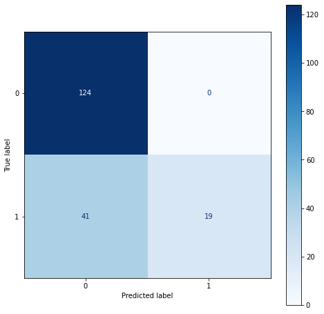

```python
print('Матрица несоответствий метода "Случайный лес":\n')
fig, ax = plt.subplots(figsize=(8, 8))
disp = ConfusionMatrixDisplay(confusion_matrix(y_test, clf_best_rf.predict(X_test)))
disp.plot(cmap = 'Blues', ax=ax);
```

```python
print ('F1 score:', f1_score(y_test, clf_best_rf.predict(X_test)))
print ('Recall:', recall_score(y_test, clf_best_rf.predict(X_test)))
print ('Precision:', precision_score(y_test, clf_best_rf.predict(X_test)))
print ('\n clasification report:\n', classification_report(y_test, clf_best_rf.predict(X_test)))
```

```
F1 score: 0.4810126582278481
Recall: 0.31666666666666665
Precision: 1.0

 clasification report:
               precision    recall  f1-score   support

           0       0.75      1.00      0.86       124
           1       1.00      0.32      0.48        60

    accuracy                           0.78       184
   macro avg       0.88      0.66      0.67       184
weighted avg       0.83      0.78      0.74       184
```

**Итог: accuracy = 78%**

## LDA

```
Точность модели на обучающей выборке:  0.9
Точность модели на тестовой выборке:  0.84
Матрица несоответствий метода "Линейный дискриминантный анализ":
```

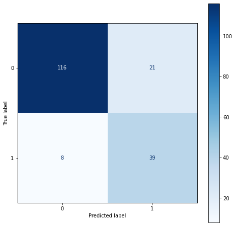

```python
LDA_model = LinearDiscriminantAnalysis()
LDA_model.fit(X_train, y_train)
LDA_prediction = LDA_model.predict(X_test)

LDA_train_accuracy = LDA_model.score(X_train, y_train)
LDA_test_accuracy = LDA_model.score(X_test, y_test)
print ('Точность модели на обучающей выборке: ', round (LDA_train_accuracy, 2))
print ('Точность модели на тестовой выборке: ', round (LDA_test_accuracy, 2))

print('Матрица несоответствий метода "Линейный дискриминантный анализ":\n')

fig, ax = plt.subplots(figsize=(8, 8))
disp = ConfusionMatrixDisplay(confusion_matrix(LDA_prediction, y_test))
disp.plot(cmap = 'Blues', ax=ax);
```

```python
print ('F1 score:', f1_score(y_test, LDA_model.predict(X_test)))
print ('Recall:', recall_score(y_test, LDA_model.predict(X_test)))
print ('Precision:', precision_score(y_test, LDA_model.predict(X_test)))
print ('\n clasification report:\n', classification_report(y_test, LDA_model.predict(X_test)))
```

```
F1 score: 0.7289719626168223
Recall: 0.65
Precision: 0.8297872340425532

 clasification report:
               precision    recall  f1-score   support

           0       0.85      0.94      0.89       124
           1       0.83      0.65      0.73        60

    accuracy                           0.84       184
   macro avg       0.84      0.79      0.81       184
weighted avg       0.84      0.84      0.84       184
```

**Итог: accuracy = 84%**

## Бустинг (AdaBoost)

Бустинг представляет собой жадный алгоритм построения композиции алгоритмов. Основная идея заключается в том, чтобы, имея множество относительно слабых алгоритмов обучения, построить их хорошую линейную комбинацию. Он похож на бэггинг тем, что базовый алгоритм обучения фиксирован. Отличие состоит в том, что обучение базовых алгоритмов для композиции происходит итеративно, и каждый следующий алгоритм стремится компенсировать недостатки композиции всех предыдущих алгоритмов.

Используя различные аппроксимации для пороговой функции потерь $[z < 0]$, будем получать различные виды бустинга. Пример:

- $e^{-z}$ - AdaBoost

Сделаем **AdaBoost** для деревьев (пеньков скорее так как желательно использовать недообучающиеся модели)

## Метод адаптивного бустинга:

```python
bdt = AdaBoostClassifier(DecisionTreeClassifier(max_depth=2,
                                                min_samples_split=20, min_samples_leaf=5),
                         algorithm="SAMME",n_estimators=100, learning_rate=0.8)
bdt.fit(X_train, y_train)
```

```
AdaBoostClassifier(algorithm='SAMME',
                   base_estimator=DecisionTreeClassifier(max_depth=2,
                                                         min_samples_leaf=5,
                                                         min_samples_split=20),
                   learning_rate=0.8, n_estimators=100)
```

```python
print ('\n clasification report:\n', classification_report(y_test, bdt.predict(X_test)))
```

```
 clasification report:
               precision    recall  f1-score   support

           0       0.80      0.98      0.88       124
           1       0.94      0.50      0.65        60

    accuracy                           0.83       184
   macro avg       0.87      0.74      0.77       184
weighted avg       0.85      0.83      0.81       184
```

Найдем лучшие параметры вариируя параетры бустинга:

```python
bdt = AdaBoostClassifier(DecisionTreeClassifier(random_state=17, max_depth=2,
                                                min_samples_split=20, min_samples_leaf=5))
par = {'n_estimators': range(300, 500, 100),
     'learning_rate': [x / 10.0 for x in range(7, 9, 1)] }
search = GridSearchCV(bdt, par, cv=4, n_jobs=-1)
search.fit(X_train, y_train)
print('search.best_params_')
bdt_best = search.best_estimator_
bdt_best.fit(X_train, y_train)
```

```
search.best_params_
```

```
AdaBoostClassifier(base_estimator=DecisionTreeClassifier(max_depth=2,
                                                         min_samples_leaf=5,
                                                         min_samples_split=20,
                                                         random_state=17),
                   learning_rate=0.8, n_estimators=300)
```

```
Матрица несоответствий метода "AdaBoost":
```

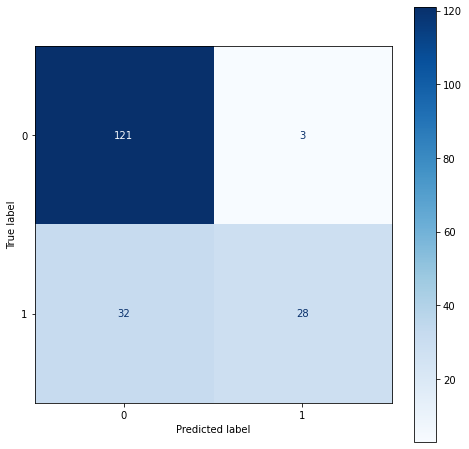

```python
print('Матрица несоответствий метода "AdaBoost":\n')
fig, ax = plt.subplots(figsize=(8, 8))
disp = ConfusionMatrixDisplay(confusion_matrix(y_test, bdt_best.predict(X_test)))
disp.plot(cmap = 'Blues', ax=ax);
```

```python
print ('\n clasification report:\n', classification_report(y_test, bdt_best.predict(X_test)))
```

```
 clasification report:
               precision    recall  f1-score   support

           0       0.79      0.98      0.87       124
           1       0.90      0.47      0.62        60

    accuracy                           0.81       184
   macro avg       0.85      0.72      0.74       184
weighted avg       0.83      0.81      0.79       184
```

**Итог: accuracy = 81%**

## Метод Градиентного бустинга:

Подберем наилучший параметр learning rate:

```python
# get the dataset
def get_dataset():
    X, y = make_classification(n_samples=1000, n_features=20, n_informative=15, n_redundant=5, random_state=7)
    return X, y

# get a list of models to evaluate
def get_models():
    models = dict()
    # define learning rates to explore
    for i in [0.01, 0.1, 0.5]:
        key = '%.4f' % i
        models[key] = GradientBoostingClassifier(learning_rate=i)
    return models

# evaluate a given model using cross-validation
def evaluate_model(model, X, y):
    # define the evaluation procedure
    # evaluate the model and collect the results
    scores = cross_val_score(model, X, y_train, scoring='accuracy', cv=10, n_jobs=-1)
    return scores

# define dataset
X, y = get_dataset()
# get the models to evaluate
models = get_models()
# evaluate the models and store results
results, names = list(), list()
for name, model in models.items():
    # evaluate the model
    scores = evaluate_model(model, X_train, y_train)
    # store the results
    results.append(scores)
    names.append(name)
```

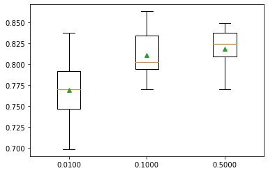

```python
pyplot.boxplot(results, labels=names, showmeans=True)
pyplot.show()
```

```python
# define the model with default hyperparameters
model = GradientBoostingClassifier()
# define the grid of values to search
grid = dict()
grid['n_estimators'] = [30, 50, 100]
grid['learning_rate'] = [0.1]
grid['max_depth'] = [2, 3, 4]
# define the grid search procedure
grid_search = GridSearchCV(estimator=model, param_grid=grid,
                           n_jobs=-1, cv=10, scoring='accuracy')
# execute the grid search
grid_result = grid_search.fit(X_train, y_train)
# summarize the best score and configuration
print("Best: %f using %s" % (grid_result.best_score_, grid_result.best_params_))
# summarize all scores that were evaluated
means = grid_result.cv_results_['mean_test_score']
stds = grid_result.cv_results_['std_test_score']
params = grid_result.cv_results_['params']
for mean, stdev, param in zip(means, stds, params):
    print("%f (%f) with: %r" % (mean, stdev, param))
```

```
Best: 0.816586 using {'learning_rate': 0.1, 'max_depth': 2, 'n_estimators': 100}
0.778508 (0.023771) with: {'learning_rate': 0.1, 'max_depth': 2, 'n_estimators': 30}
0.785339 (0.020838) with: {'learning_rate': 0.1, 'max_depth': 2, 'n_estimators': 50}
0.816586 (0.019432) with: {'learning_rate': 0.1, 'max_depth': 2, 'n_estimators': 100}
0.793484 (0.025672) with: {'learning_rate': 0.1, 'max_depth': 3, 'n_estimators': 30}
0.801648 (0.031114) with: {'learning_rate': 0.1, 'max_depth': 3, 'n_estimators': 50}
0.812514 (0.036688) with: {'learning_rate': 0.1, 'max_depth': 3, 'n_estimators': 100}
0.789356 (0.027709) with: {'learning_rate': 0.1, 'max_depth': 4, 'n_estimators': 30}
0.801629 (0.031699) with: {'learning_rate': 0.1, 'max_depth': 4, 'n_estimators': 50}
0.809793 (0.032059) with: {'learning_rate': 0.1, 'max_depth': 4, 'n_estimators': 100}
```

```
Матрица несоответствий метода "Градиентный бустинг":
```

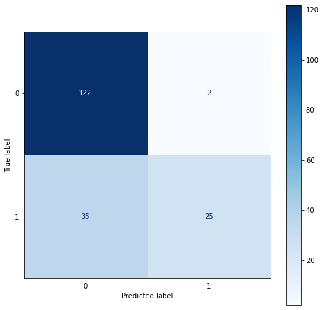

```python
print('Матрица несоответствий метода "Градиентный бустинг":\n')
fig, ax = plt.subplots(figsize=(8, 8))
disp = ConfusionMatrixDisplay(confusion_matrix(y_test, grid_result.predict(X_test)))
disp.plot(cmap = 'Blues', ax=ax);
```

```python
print ('F1 score:', f1_score(y_test, grid_result.predict(X_test)))
print ('Recall:', recall_score(y_test, grid_result.predict(X_test)))
print ('Precision:', precision_score(y_test, grid_result.predict(X_test)))
print ('\n clasification report:\n', classification_report(y_test, grid_result.predict(X_test)))
```

```
F1 score: 0.5747126436781609
Recall: 0.4166666666666667
Precision: 0.9259259259259259

 clasification report:
               precision    recall  f1-score   support

           0       0.78      0.98      0.87       124
           1       0.93      0.42      0.57        60

    accuracy                           0.80       184
   macro avg       0.85      0.70      0.72       184
weighted avg       0.83      0.80      0.77       184
```

Данный алгоритм показывает такое невысокое качество из-за того, что число признаков слишком велико по отношению к числу самих данных. В данном случае более простые алгоритмы лучше справляются с задачей. При большом числе данных данный метод один из лучших.

**Итог: accuracy = 80%**

## Логистическая регрессия

```
Точность модели на обучающей выборке:  0.91
Точность модели на тестовой выборке:  0.83
Матрица несоответствий метода "Логистическая регрессия":
```

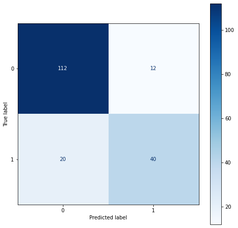

```python
LR_model = LogisticRegression(solver='liblinear')
# Обучим модель на обучающей выборке
LR_model.fit(X_train, y_train)
# Предскажем класс тестовой выборки
LR_prediction = LR_model.predict(X_test)

LR_train_accuracy = LR_model.score(X_train, y_train)
LR_test_accuracy = LR_model.score(X_test, y_test)
print ('Точность модели на обучающей выборке: ', round (LR_train_accuracy, 2))
print ('Точность модели на тестовой выборке: ', round (LR_test_accuracy, 2))

print('Матрица несоответствий метода "Логистическая регрессия":\n')
fig, ax = plt.subplots(figsize=(8, 8))
disp = ConfusionMatrixDisplay(confusion_matrix(y_test, LR_model.predict(X_test)))
disp.plot(cmap = 'Blues', ax=ax);
```

```python
print ('F1 score:', f1_score(y_test, LR_model.predict(X_test)))
print ('Recall:', recall_score(y_test, LR_model.predict(X_test)))
print ('Precision:', precision_score(y_test, LR_model.predict(X_test)))
print ('\n clasification report:\n', classification_report(y_test, LR_model.predict(X_test)))
```

```
F1 score: 0.7142857142857142
Recall: 0.6666666666666666
Precision: 0.7692307692307693

 clasification report:
               precision    recall  f1-score   support

           0       0.85      0.90      0.88       124
           1       0.77      0.67      0.71        60

    accuracy                           0.83       184
   macro avg       0.81      0.78      0.79       184
weighted avg       0.82      0.83      0.82       184
```

**Итог: accuracy = 83%**

## KNN

```python
clf = KNeighborsClassifier()
par = {'n_neighbors': range(1, 15)}
search = GridSearchCV(clf, par, cv=5, n_jobs=-1)
search.fit(X_train, y_train)
search.best_params_
```

```
{'n_neighbors': 7}
```

```
Точность модели на обучающей выборке:  0.73
Точность модели на тестовой выборке:  0.71
Матрица несоответствий метода "KNN":
```

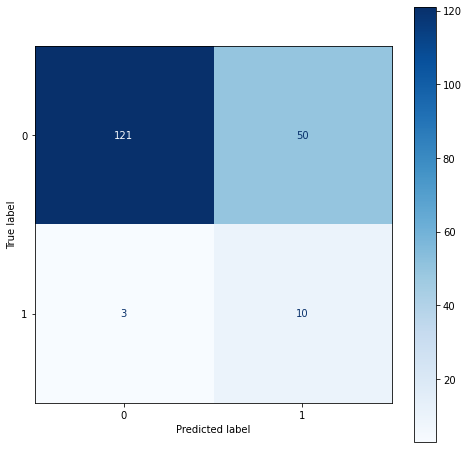

```python
KNN_model = KNeighborsClassifier(n_neighbors = 7)
KNN_model.fit(X_train, y_train)
KNN_prediction = KNN_model.predict(X_test)

KNN_train_accuracy = KNN_model.score(X_train, y_train)
KNN_test_accuracy = KNN_model.score(X_test, y_test)
print ('Точность модели на обучающей выборке: ', round (KNN_train_accuracy, 2))
print ('Точность модели на тестовой выборке: ', round (KNN_test_accuracy, 2))

fig, ax = plt.subplots(figsize=(8, 8))
print('Матрица несоответствий метода "KNN":\n')
disp = ConfusionMatrixDisplay(confusion_matrix(KNN_prediction, y_test))
disp.plot(cmap = 'Blues', ax=ax);
```

Один из самых низких показателей на тестовой выборке  
**Итог: accuracy = 71%**

## Наивный байесовский алгоритм классификации:

```
Точность модели на обучающей выборке:  0.81
Точность модели на тестовой выборке:  0.75
Матрица несоответствий метода "Наивный байесовский алгоритм":
```

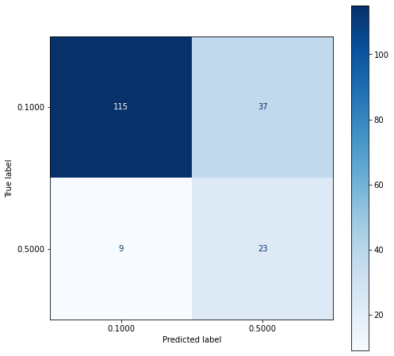

```python
GNB_model = GaussianNB()
GNB_model.fit(X_train, y_train)
GNB_prediction = GNB_model.predict(X_test)

GNB_train_accuracy = GNB_model.score(X_train, y_train)
GNB_test_accuracy = GNB_model.score(X_test, y_test)
print ('Точность модели на обучающей выборке: ', round (GNB_train_accuracy, 2))
print ('Точность модели на тестовой выборке: ', round (GNB_test_accuracy, 2))

fig, ax = plt.subplots(figsize=(8, 8))
print('Матрица несоответствий метода "Наивный байесовский алгоритм":\n')
disp = ConfusionMatrixDisplay(confusion_matrix(GNB_prediction, y_test), display_labels = names[1:])
disp.plot(cmap = 'Blues', ax=ax);
```

**Итог: accuracy = 75%**

## Метод опорных векторов:

```python
clf = SVC()
par={'degree': range(1,15)}
search=GridSearchCV(clf, par, cv=5, n_jobs=-1)
search.fit(X_train, y_train)
search.best_params_
```

```
{'degree': 1}
```

```
Точность модели на обучающей выборке:  0.85
Точность модели на тестовой выборке:  0.84
Матрица несоответствий метода опорных векторов:
```

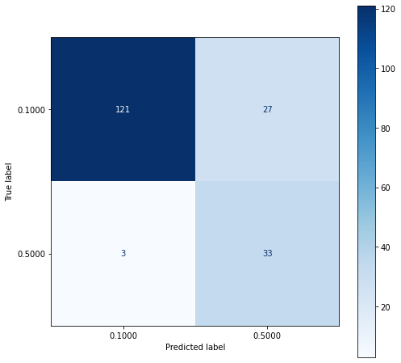

```python
SVC_model = SVC(gamma='scale', kernel='poly', degree=1)
SVC_model.fit(X_train, y_train)
SVC_prediction = SVC_model.predict(X_test)

SVC_train_accuracy = SVC_model.score(X_train, y_train)
SVC_test_accuracy = SVC_model.score(X_test, y_test)
print ('Точность модели на обучающей выборке: ', round (SVC_train_accuracy, 2))
print ('Точность модели на тестовой выборке: ', round (SVC_test_accuracy, 2))

fig, ax = plt.subplots(figsize=(8, 8))
print('Матрица несоответствий метода опорных векторов:\n')
disp = ConfusionMatrixDisplay(confusion_matrix(SVC_prediction, y_test), display_labels = names[1:])
disp.plot(cmap = 'Blues', ax=ax);
```

**Итог: accuracy = 84%**

### Таким образом, лучшими алгоритмами для данной задачи стали: линейный дискриминантный анализ для задачи бинарной классификации и метод опорных векторов с линейным ядром, осуществеленные после снижения размерности с помощью метода главных компонент (оставление 90 % дисперсии исходных данных).